# W3cubDocs

/npm

# Deleting your npm user account

From the web, you can delete your npm user account.

1. [Log in](https://www.npmjs.com/login) to npm with your user account.

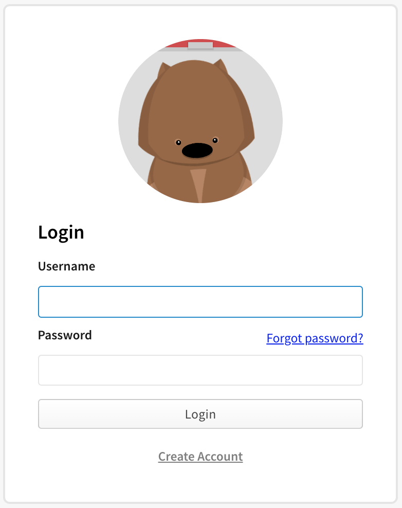

2. In the upper right corner of the page, click your profile picture, then click **Account**.

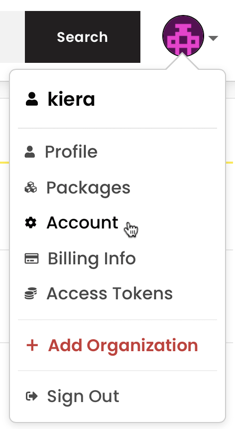

3. On this page, you will find a button to delete your account. Click that.

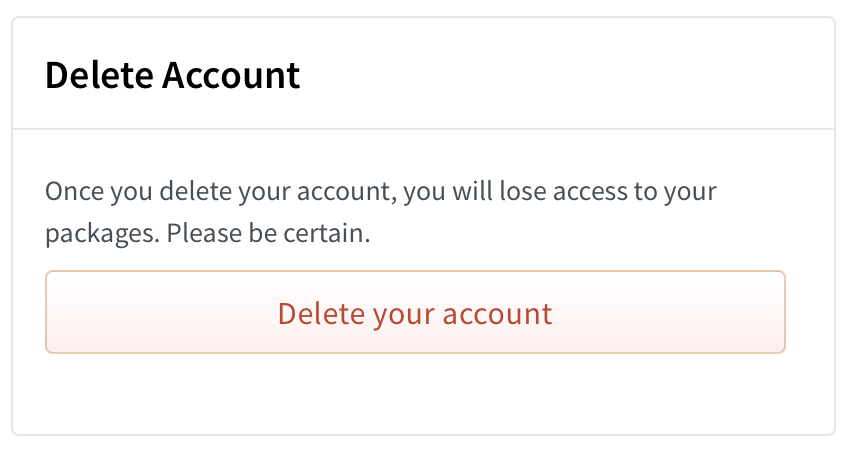

4. You will now be presented with an overview of how many npm packages will be deleted and deprecated as part of your account deletion. If you agree with this, then enter your username and click "Delete this account".

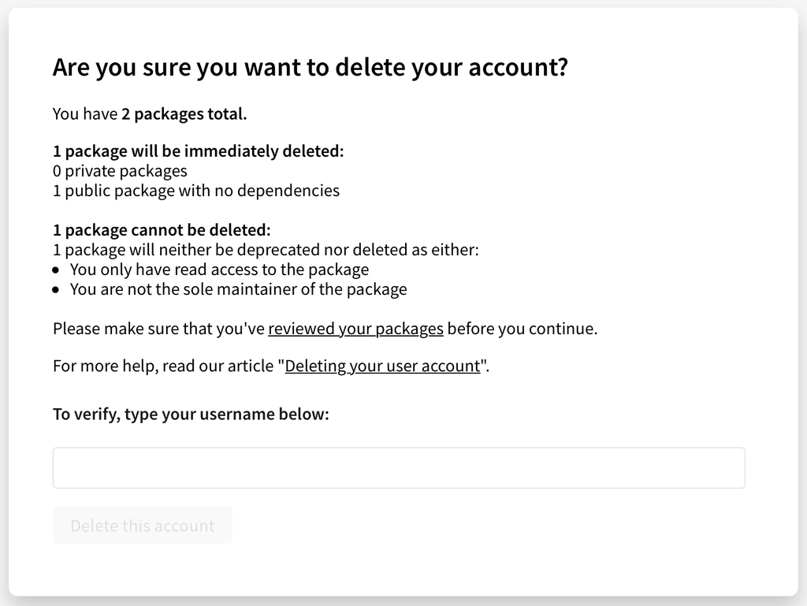

5. You will be immediately logged out, and will not be able to log back in.

In some cases, you will be presented with an error if we were unable to automatically delete your account. For example. if you are the sole owner of an organization you will need to add an additional owner before your account can be deleted. You will be presented clear instructions of what you will need to do in order to delete your account.

If you are in doubt about deleting your account, [contact npm Support](https://www.npmjs.com/support).

© npm, Inc. and Contributors  
Licensed under the npm License.  
npm is a trademark of npm, Inc.  
https://docs.npmjs.com/deleting-your-npm-user-account